# Buliding Blocks for Constructing Bounds: Part 1

Extending the Policy Evaluation Toolkit

Partial Identification

Causal Inference

Author

John Graves

Published

December 19, 2022

# Introduction

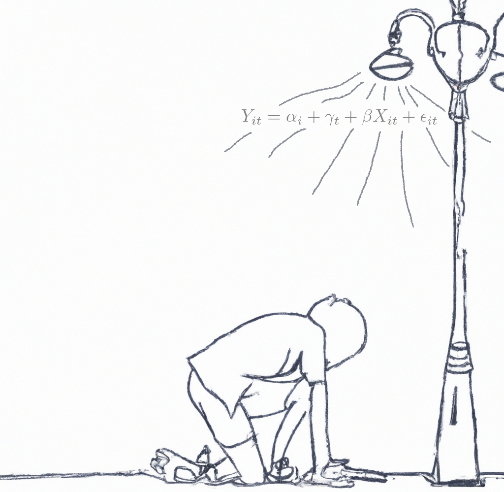

- This part will cover causal inference as a missing data issue.
- It will also cover shortfalls of point identification
  - Strong assumptions
  - Sensitivity to functional form
- Partial identification methods offer new objects of interest
  - Quantities of interest not point identified, even in RCTs
    - Fraction of the population harmed or hurt by an intervention.
  - Not as sensitive to functional form (e.g., parallel trends in logs or levels)?

Basic structure can start with CI as a missing data problem.

- Missing information on potential outcomes.
- This restricts the quantities of interest we can point identify, since we don’t observe the “coupling” of both potential outcomes.
  - Can’t, for example, identify the fraction of the population harmed by an intervention.
    - We might estimate that the ATE is “good,” on average, but this doesn’t mean *everyone* is better off.
  - Distribution of the treatment effect
- Various identification methods bring assumptions that allow us to identify various quantities of interest.
  - ATET

# Data Generation Process

```r
params <-
  list(
    N = 2e3,
    sigma_sq_X = 1.0,
    sigma_sq_epsilon = 0.3,
    delta = 1
  )
params <- with(params,
               modifyList(params,list(
                 r_squared = 1 - sigma_sq_epsilon,
                 beta = sqrt(1 - sigma_sq_epsilon),
                 Sigma = matrix(c(sigma_sq_X,0,0,sigma_sq_epsilon),
                                byrow=TRUE, nrow = 2, ncol = 2))))

gen_data <- function(params) {
  with(params,
       mvrnorm(n = N, mu = c(0,0), Sigma = Sigma)) %>%
    data.frame() %>%
    as_tibble() %>%
    set_names(c("X","epsilon")) %>%
    mutate(Y_i0 = params$beta * X + epsilon) %>%
    mutate(Y_i1 = Y_i0 + params$delta) %>%
    mutate(random = runif(nrow(.))) %>%
    mutate(D = as.integer(row_number()<=(params$N)/2)) %>%
    arrange(random) %>%
    select(-random) %>%
    mutate(Y = D * Y_i1 + (1 - D) * Y_i0) %>%
    select(Y,D,X)
}

set.seed(123)
df <- params %>% gen_data()

df %>% head(n=10) %>% kable() %>%
    kable_styling()
```

Table 1: First 10 rows of data

| Y | D | X |
| --- | --- | --- |
| 0.636525 | 0 | 1.136893 |
| -1.017545 | 0 | -1.143835 |
| -2.660006 | 0 | -1.769366 |
| -0.234232 | 0 | -1.314321 |
| -0.552531 | 1 | -1.236676 |
| -0.082499 | 0 | -1.321069 |
| 1.784970 | 1 | 1.516068 |
| 0.771550 | 1 | 0.246692 |
| -0.690019 | 0 | -1.433008 |
| -0.084229 | 0 | -0.229395 |

# Generating an Empirical Cumulative Distribution Function

Let’s define some useful objects:

```r
y1 <- # Vector of treated outcomes
    df %>% filter(D==1) %>% pull(Y)

y0 <- # Vector of untreated outcomes
    df %>% filter(D==0) %>% pull(Y)

y_ <- # Vector of the support of the outcome, with 100 evenly-spaced values along it.
    seq(floor(min(y0,y1))-1,ceiling(max(y0,y1))+1, length.out = 100)
```

Our first option is to construct by hand. This type of approach will come in handy later when we want to construct a conditional CDF.

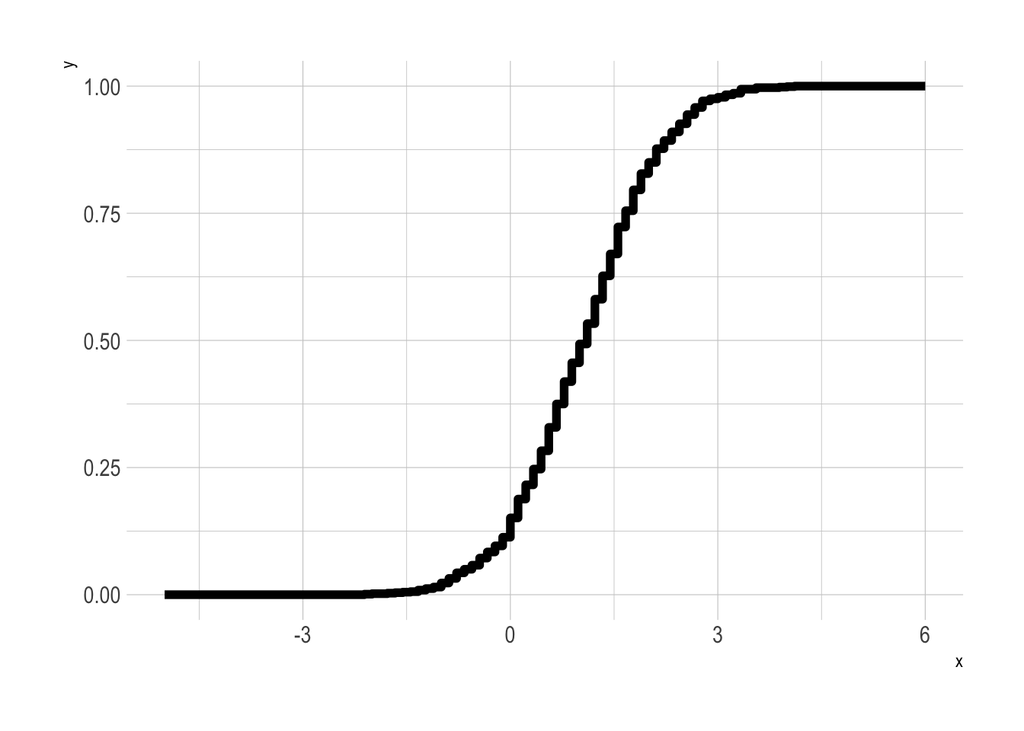

Figure 1: Constructed Empirical Cumulative Distribution Function

```r
eCDF_y1 <-
    y_ %>% # Iterate over the support of y
    map_dbl(~({
        IY = as.integer(y1 <= .x)
        mean(IY)
    }))
p0 <-  # Plot the constructed eCDF
    tibble(x = y_, y = eCDF_y1, method = "Constructed") %>%
    ggplot(aes(x = x, y = y)) + geom_step(lwd=2)
p0
```

A second option is to simply use the R command `ecdf()`. This command creates a function that we can feed y values to to get their quantile in the distribution. Let’s overlay the plot with an eCDF constructed this way in yellow:

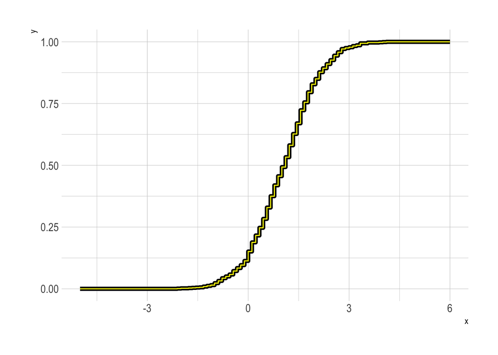

Figure 2: Constructed Empirical Cumulative Distribution Function

```r
eCDF_y1_v2 <- ecdf(y1)
df_v2 <- tibble(x = y_, y = eCDF_y1_v2(y_), method = "ecdf()")
p0 +
    geom_step(data = df_v2, col = "yellow")
```

Figure 1 and Figure 2 are both step functions—but occasionally we may need a smoothed version because the empirically-estimated version is a bit lumpy (e.g., it may not conform to the requirement that the cdf monotonically increases and is bounded by 0 and 1). We can address this by fitting a smooth function to the points, and imposing the necessary shape constraint for a CDF (i.e., monotonically increasing, between 0 and 1) using the methods [here](https://link.springer.com/article/10.1007/s11222-013-9448-7). This can be done using the R package `scam`, and using code inspired by [this source](https://stackoverflow.com/questions/51438627/get-the-derivative-of-an-ecdf).

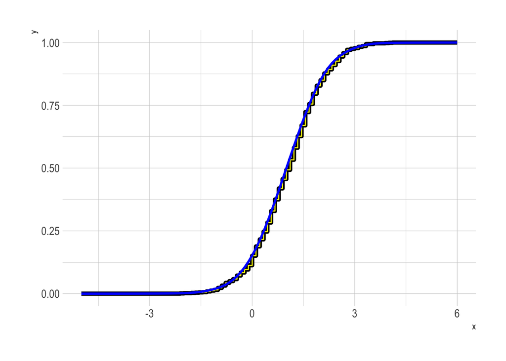

Figure 3: Constructed Empirical Cumulative Distribution Functions

```r
dat <-
    tibble(x = y_, cdf = ecdf(y1)(y_))
n.knots = 20
n <- length(dat$x)
fit <-
    scam::scam(cdf ~ s(x, bs = "mpi", k = n.knots),
               data = dat,
               weights = c(n, rep(1, n - 2), 10 * n))
## interior knots
xk <- with(fit$smooth[[1]], knots[4:(length(knots) - 3)])
## spline values at interior knots
yk <- predict(fit, newdata = data.frame(x = xk))
## reparametrization into a monotone interpolation spline
xg <- seq(min(dat$x), max(dat$x), length = 100)
f <- stats::splinefun(xk, yk, "hyman")
dat$cdf_sm = f(y_)

p0 +
    geom_step(data = df_v2, col = "yellow") +
    geom_line(data = dat, aes(y = cdf_sm), col = "blue",lwd=1.1)
```

# Conditional CDFs

First, the long way …

```r
i1 <-  # index of treated observations
  df %>%
  mutate(i = row_number()) %>%
  filter(D==1) %>%
  pull(i)

i0 <-  # index of untreated observations
  df %>%
  mutate(i = row_number()) %>%
  filter(D==0) %>%
  pull(i)

X1 <- # X values of treated observations
  df %>%
  filter(D==1) %>%
  pull(X)

X0 <- # X values of untreated observations
  df %>%
  filter(D==0) %>%
  pull(X)

library(tictoc)
tic()
hatFX_ <-
    y0[c(25,50)] %>%
    map(~{
        i <- which(y0==.x); i
        res_ <- map_dbl(y0,~({
            IY = as.integer(y0 <= .x)
            X <- X0
            df_ <- data.frame(IY = IY , X = X)
            fit <- gam(IY ~ s(X), data = df_, family = "binomial")
            predict(fit, newdata = data.frame(X = X0[i]), type = "response")
        }))
        BMisc::makeDist(y0,res_)
    })
time1 <- toc()
```

```
75.796 sec elapsed
```

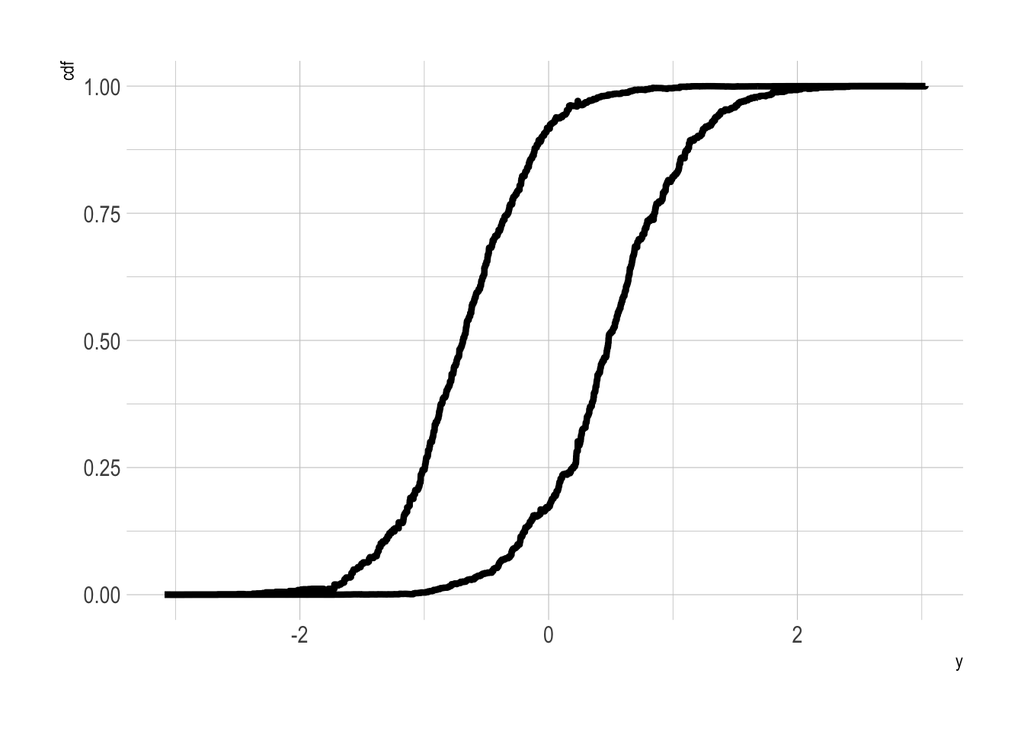

Figure 4: Conditional Empirical Cumulative Distribution Function

```r
p1 <-
  tibble(y = c(y0,y0), cdf = c(hatFX_[[1]](y0),hatFX_[[2]](y0)),id = c(rep("A",length(y0)),rep("B",length(y0)))) %>%
  ggplot(aes(x = y, y = cdf, group = id)) +
  geom_step(lwd=1.5)

p1
```

$$F_{Y_{j} \mid X_{j}}(y \mid x) \equiv \int_{(0,1)} 1\left\{Q_{Y_{j} \mid X_{j}}(u \mid x) \leq y\right\} d u$$

$$\hat{F}_{Y_{j} \mid X_{j}}(y \mid x)=\varepsilon+\int_{(\varepsilon, 1-\varepsilon)} 1\left\{x^{\prime} \hat{\beta}_{j}(u) \leq y\right\} d u$$

$$\hat{\beta}_{j}(u)=\arg \min _{b \in \mathbb{R}^{d x}} \sum_{i=1}^{n_{j}}\left[u-1\left\{Y_{j i} \leq X_{j i}^{\prime} b\right\}\right]\left[Y_{j i}-X_{j i}^{\prime} b\right]$$

[output not shown]

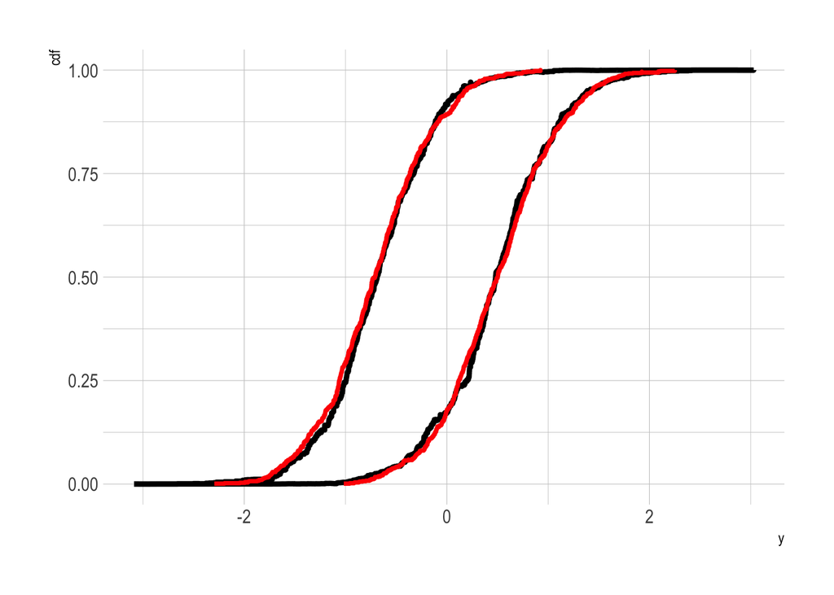